# Introduction to Data Science - HW 2

Kody Byrd - `kbyrd4000@floridapoly.edu`

```r
library("stringr")
```

# Problem 1 (20 points)

During class you completed an activity in which you practiced `git` commands and operations (such as forking a repository, cloning it using `git clone`, and uploading changes using `git push`).

In this exercise you will used **markdown** tools discussed in class.

## Part A

You must **create a table** that shows the courses you are currently enrolled in, using the following for the headers of the table:

- Prefix: in bold letters (such as **COP**)
- Number: in bold letters (such as **2073**)
- Name: in italics (such as *Introduction to Data Science*)
- Credits (such as 3)

| **Class Name** | **Class Number** | **Credits** |
| --- | --- | --- |
| **Into to Comp and Programming** | **2271** | 3 |
| **Into to Data Science** | **2073** | 3 |
| **Python for Data Analytics** | **2310** | 3 |
| **Analytic Geometry and Calculus 1** | **2311** | 4 |

## Part B

Take a screenshot of the GitHub repo you used in HW 01, add the screenshot file to the repo, and include it in this document (review how to insert a picture using markdown).

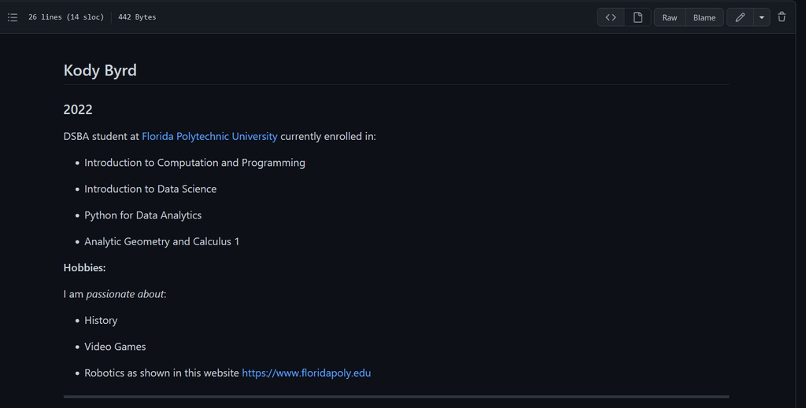

picture of HW1

# Problem 2 (30 points)

# Problem 3 (25 points)

In this problem you will practice some basic R operations. Include solutions to each items by inserting a new R chunk of code (make sure you run the chunk so that the output is displayed)

1. Create a variable called `my_name` that contains *your preferred name*.

```r
myName <- 'Kody Byrd'
print(myName)
```

```
## [1] "Kody Byrd"
```

2. Create a variable called `name_length` that holds how many letters are in `my_name`.

```r
name_length <- str_count(myName)
print(name_length)
```

```
## [1] 9
```

3. Show which value is bigger: $e^\pi$ or $\pi^e$. (Use the correct expressions for Euler’s constant $e$ and the irrational number $\pi$ in R)

```r
if((exp(1) ^ pi) > (pi ^ exp(1))){
    print('e^pi is the larger number')
}else
{
    print('pi^e is the larger number')
  }
```

```
## [1] "e^pi is the larger number"
```

4. Use the colon operator `:` to create a vector `v` of numbers from 31 to 86. Find the length of this vector using the `length()` function.

```r
v <- c(31:86)
length_v <- length(v)
print(length_v)
```

```
## [1] 56
```

5. Use the `seq()` function to produce a range of number from -5 to 10 in 0.5 increments.

```r
seq(-5,10,0.5)
```

```
##  [1] -5.0 -4.5 -4.0 -3.5 -3.0 -2.5 -2.0 -1.5 -1.0 -0.5  0.0  0.5  1.0  1.5  2.0
## [16]  2.5  3.0  3.5  4.0  4.5  5.0  5.5  6.0  6.5  7.0  7.5  8.0  8.5  9.0  9.5
## [31] 10.0
```

# Problem 4 (25 points)

1. (10 points) Define a function `imperial_to_metric` that takes in **two arguments**: a number of feet and a number of inches. The function should return the equivalent length in meters

> To convert a length `L` from feet (`ft`) and inches (`inches`) to meters (`m`), one can use the relation: `L(m) = L(ft) × 0.3048 + L(inches) × 0.0254`

```r
imperial_to_metric <- function(feet,inches){
  meters = (feet * 0.3048) + (inches * 0.0254)
  return(meters)
}
```

```r
imperial_to_metric(3,0)
```

```
## [1] 0.9144
```

2. (5 points) Create a variable `height_in_meters` by passing your height in imperial to the `imperial_to_metric` function.

```r
height_in_meters <- imperial_to_metric(5,8)
print(height_in_meters)
```

```
## [1] 1.7272
```

3. (5 points) Evaluate `round(3.1415)`, `factorial(12)`, `mean(1:17)`.

```r
round(3.1415)
```

```
## [1] 3
```

```r
factorial(12)
```

```
## [1] 479001600
```

```r
mean(1:17)
```

```
## [1] 9
```

4. (5 points) Create an object named `die` that contains the numbers one through six. Simulate a roll of the die with `R`’s `sample()` function.

```r
die <- sample(6, replace = TRUE)
print(die)
```

```
## [1] 2 2 1 2 1 2
```